# Data Science Homework 3

Caroline Andy

10/10/2020

## Problem 1

First I will load my required packages, including p8105.datasets, which we will use for this problem. I will also set my figure preferences in global options.

```r
library(tidyverse)
```

```r
library(p8105.datasets)

knitr::opts_chunk$set(
  fig.width = 6,
  fig.asp = 0.6,
  out.width = "90%"
)
```

Now I will load my data.

```r
data("instacart")
```

How many aisles, and which are most items from?

```r
instacart %>%
  count(aisle) %>%
  arrange(desc(n))
```

```
## # A tibble: 134 x 2
##    aisle                              n
##    <chr>                          <int>
##  1 fresh vegetables              150609
##  2 fresh fruits                  150473
##  3 packaged vegetables fruits     78493
##  4 yogurt                         55240
##  5 packaged cheese                41699
##  6 water seltzer sparkling water  36617
##  7 milk                           32644
##  8 chips pretzels                 31269
##  9 soy lactosefree                26240
## 10 bread                          23635
## # … with 124 more rows
```

Make a plot showing the number of items ordered in each isle. Only include aisles with +10,000 items purchased.

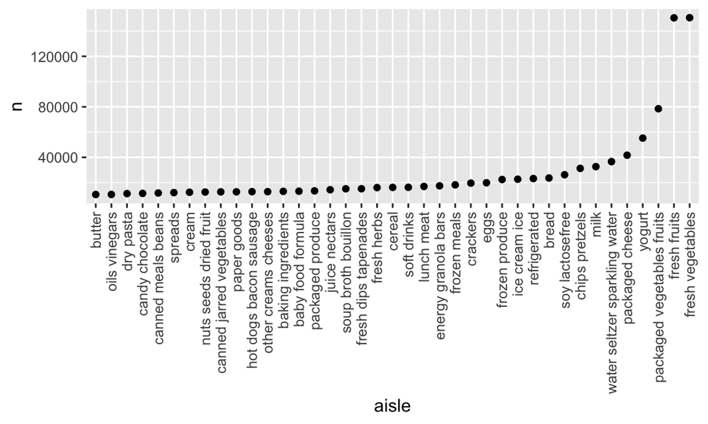

```r
instacart %>%
  count(aisle) %>%
  filter(n > 10000) %>%
  mutate(
    aisle = factor(aisle),
    aisle = fct_reorder(aisle, n)
  ) %>%
  ggplot(aes(x = aisle, y = n)) +
  geom_point() +
  theme(axis.text.x = element_text(angle = 90, vjust = 0.5, hjust = 1))
```

Make a table containing three most population items in each of the aisles “baking ingredients,” “dog food care,” and “packaged vegetable fruits.” Include the number of times each item is ordered in your table.

First let’s pull out different aisles, then we will count up most popular items within each aisle.

```r
instacart %>%
  filter(aisle %in% c("baking ingredients", "dog food care", "packaged vegetables fruits")) %>%
  group_by(aisle) %>%
  count(product_name) %>%
  mutate(rank = min_rank(desc(n))) %>%
  filter(rank < 4) %>%
  arrange(aisle, rank) %>%
  #clean up table for Rmd
  knitr::kable()
```

| aisle | product_name | n | rank |
| --- | --- | --- | --- |
| baking ingredients | Light Brown Sugar | 499 | 1 |
| baking ingredients | Pure Baking Soda | 387 | 2 |
| baking ingredients | Cane Sugar | 336 | 3 |
| dog food care | Snack Sticks Chicken & Rice Recipe Dog Treats | 30 | 1 |
| dog food care | Organix Chicken & Brown Rice Recipe | 28 | 2 |
| dog food care | Small Dog Biscuits | 26 | 3 |
| packaged vegetables fruits | Organic Baby Spinach | 9784 | 1 |
| packaged vegetables fruits | Organic Raspberries | 5546 | 2 |
| packaged vegetables fruits | Organic Blueberries | 4966 | 3 |

Make a table showing the mean hour of the day which Pink Lady Apples and Coffee Ice Cream are ordered on each day of the week.

```r
instacart %>%
  filter(product_name %in% c("Pink Lady Apples", "Coffee Ice Cream")) %>%
  group_by(product_name, order_dow) %>%
  summarize(mean_hour = mean(order_hour_of_day)) %>%
  pivot_wider(
    names_from = order_dow,
    values_from = mean_hour
  )
```

```
## # A tibble: 2 x 8
## # Groups:   product_name [2]
##   product_name       `0`   `1`   `2`   `3`   `4`   `5`   `6`
##   <chr>            <dbl> <dbl> <dbl> <dbl> <dbl> <dbl> <dbl>
## 1 Coffee Ice Cream  13.8  14.3  15.4  15.3  15.2  12.3  13.8
## 2 Pink Lady Apples  13.4  11.4  11.7  14.2  11.6  12.8  11.9
```

## Problem 2

I will begin by loading, cleaning and tidying in the required dataset for this problem. This problem uses five weeks of accelerometer data collected on a 63 year-old male with BMI 25, who was admitted to the Advanced Cardiac Care Center of Columbia University Medical Center and diagnosed with congestive heart failure (CHF).

```r
accel_data = read_csv("./accel_data.csv") %>%
  #clean variable names
  janitor::clean_names() %>%
  #change table formatting to longer
  pivot_longer(
    cols = starts_with("activity"),
    names_to = "minute",
    names_prefix = "activity.",
    values_to = "activity") %>%
  #create day_type variable with weekday and weekend entries
  mutate(day_type = ifelse(day %in% c("Monday", "Tuesday", "Wednesday", "Thursday", "Friday"), "Weekday", "Weekend")) %>%
  #change variable types as appropriate
  mutate(minute = as.numeric(minute)) %>%
  #reorder variables
  select(day_id, day, week, day_type, minute, activity)
##Consider reordering variables
```

The generated plot contains 50400 rows and 6 columns. The columns include a day identifier, day of the week, week number, day type (weekday vs weekend), minute, and activity level.

```r
#create a summary dataset containing activity totals for each day and week
summ.accel = accel_data %>%
  group_by(day, week) %>%
  summarise(total = sum(activity))
```

We can investigate trends associated with activity level and day of the week by grouping by day of the week and summarizing

```r
summ.day = summ.accel %>%
  group_by(day) %>%
  summarise(total = sum(total))
#we can investigate trends associated with activity level and week by grouping by week and summarizing
summ.week = summ.accel %>%
  group_by(week) %>%
  summarise(total = sum(total))
```

We can further visualize these results by generating a single-panel plot that shows the 24-hr activity time courses for each day. I will do so below, using color to indicate day of the week.

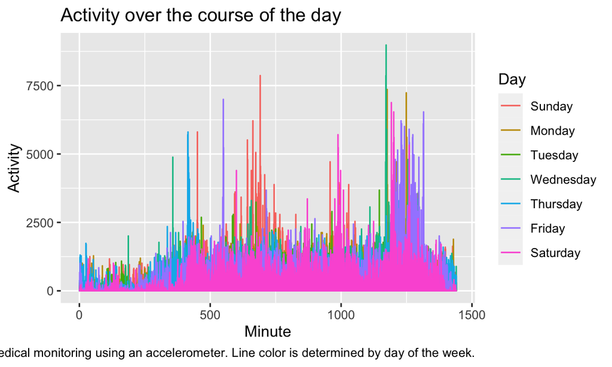

```r
plot = accel_data %>%
  mutate(day = as.factor(day)) %>%
  mutate(day = factor(day, levels = str_c(c("Sunday", "Monday", "Tuesday", "Wednesday", "Thursday", "Friday", "Saturday")))) %>%
  ggplot(aes(x = minute, y = activity, color = day)) +
  geom_line() +
  labs(
    title = "Activity over the course of the day",
      x = "Minute",
      y = "Activity",
      caption = "This graph depicts activity over the course of the day for 35 consecutive days of medical monitoring using an accelerometer. Line color is determined by day of the week."
  ) +
  guides(color = guide_legend("Day"))

plot
```

Based on the above graph, we can make several observations. Firstly, on all days of the week, activity is low during the first ~300 minutes of the day. Similarly, activity declines on all days of the week during the last ~150 minutes of the day. This suggests that the patient is sleeping during this timeframe. On Fridays,the patient sustains activity longer into the night than on other weekdays.

## Problem 3

Next, I will load in the ny_noaa from the p8105.datasets library.

The National Oceanic and Atmospheric Association (NOAA) of the National Centers for Environmental Information (NCEI) provides public access to some weather data, including the GHCN (Global Historical Climatology Network)-Daily database of summary statistics from weather stations around the world.

```r
library(p8105.datasets)
data("ny_noaa")

ny_noaa =
  ny_noaa %>%
  janitor::clean_names() %>%
  separate(date, c("year", "month", "day")) %>%
  mutate(tmax = as.numeric(tmax),
         tmin = as.numeric(tmin),
         year = as.numeric(year),
         month = as.numeric(month),
         day = as.numeric(day)) %>%
  mutate(tmax = (tmax)/10,
         tmin = (tmin)/10,
         prcp = (prcp)/100)
  skimr::skim(ny_noaa)
```

Data summary

| Name | ny_noaa |
| --- | --- |
| Number of rows | 2595176 |
| Number of columns | 9 |
| _______________________ |  |
| Column type frequency: |  |
| character | 1 |
| numeric | 8 |
| ________________________ |  |
| Group variables | None |

**Variable type: character**

| skim_variable | n_missing | complete_rate | min | max | empty | n_unique | whitespace |
| --- | --- | --- | --- | --- | --- | --- | --- |
| id | 0 | 1 | 11 | 11 | 0 | 747 | 0 |

**Variable type: numeric**

| skim_variable | n_missing | complete_rate | mean | sd | p0 | p25 | p50 | p75 | p100 | hist |
| --- | --- | --- | --- | --- | --- | --- | --- | --- | --- | --- |
| year | 0 | 1.00 | 1996.50 | 9.19 | 1981.0 | 1988.0 | 1997.0 | 2005.00 | 2010.0 | ▆▆▅▅▇ |
| month | 0 | 1.00 | 6.56 | 3.45 | 1.0 | 4.0 | 7.0 | 10.00 | 12.0 | ▇▅▅▅▇ |
| day | 0 | 1.00 | 15.73 | 8.80 | 1.0 | 8.0 | 16.0 | 23.00 | 31.0 | ▇▇▇▇▆ |
| prcp | 145838 | 0.94 | 0.30 | 0.78 | 0.0 | 0.0 | 0.0 | 0.23 | 228.6 | ▇▁▁▁▁ |
| snow | 381221 | 0.85 | 4.99 | 27.22 | -13.0 | 0.0 | 0.0 | 0.00 | 10160.0 | ▇▁▁▁▁ |
| snwd | 591786 | 0.77 | 37.31 | 113.54 | 0.0 | 0.0 | 0.0 | 0.00 | 9195.0 | ▇▁▁▁▁ |
| tmax | 1134358 | 0.56 | 13.98 | 11.14 | -38.9 | 5.0 | 15.0 | 23.30 | 60.0 | ▁▂▇▆▁ |
| tmin | 1134420 | 0.56 | 3.03 | 10.40 | -59.4 | -3.9 | 3.3 | 11.10 | 60.0 | ▁▁▇▂▁ |

For snowfall, what are the most commonly observed values? Why?

```r
ny_noaa %>%
  group_by(snow) %>%
  count(snow, name = "n_obs") %>%
  arrange(desc(n_obs))
```

```
## # A tibble: 282 x 2
## # Groups:   snow [282]
##     snow   n_obs
##    <int>   <int>
##  1     0 2008508
##  2    NA  381221
##  3    25   31022
##  4    13   23095
##  5    51   18274
##  6    76   10173
##  7     8    9962
##  8     5    9748
##  9    38    9197
## 10     3    8790
## # … with 272 more rows
```

0 mm is the most commonly observed snowfall value. Aside from this, the most commonly reported snowfall amount is 25 mm.

Next I will make a two-panel plot showing the average max temperature in January and in July in each station across years. Is there any observable / interpretable structure? Any outliers?

```r
data = filter(ny_noaa, month %in% c("1","7")) %>%
  group_by(year, month, id) %>%
  summarise(mean_tmax = mean(tmax, na.rm = TRUE))
```

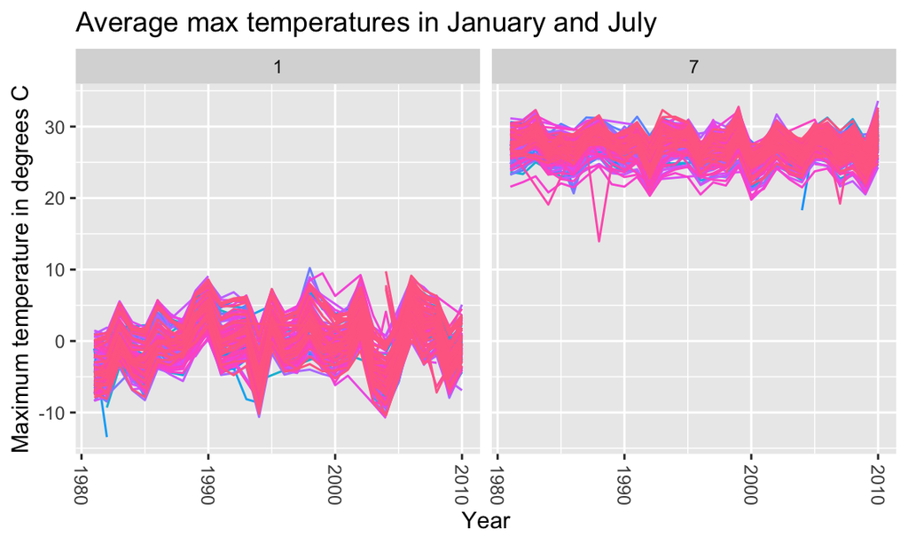

```r
ggplot(data = data, aes(x = year, y = mean_tmax, color = id)) +
  geom_line() +
  facet_grid(~ month) +
  labs(
    title = "Average max temperatures in January and July",
    x = "Year",
    y = "Maximum temperature in degrees C") +
  theme(legend.position = "none") +
  theme(axis.text.x = element_text(angle = 270, vjust = 0.5, hjust = 1))
```

Next I will make a two-panel plot showing (i) tmax vs tmin for the full dataset; and (ii) the distribution of snowfall values greater than 0 and less than 100 separately by year.

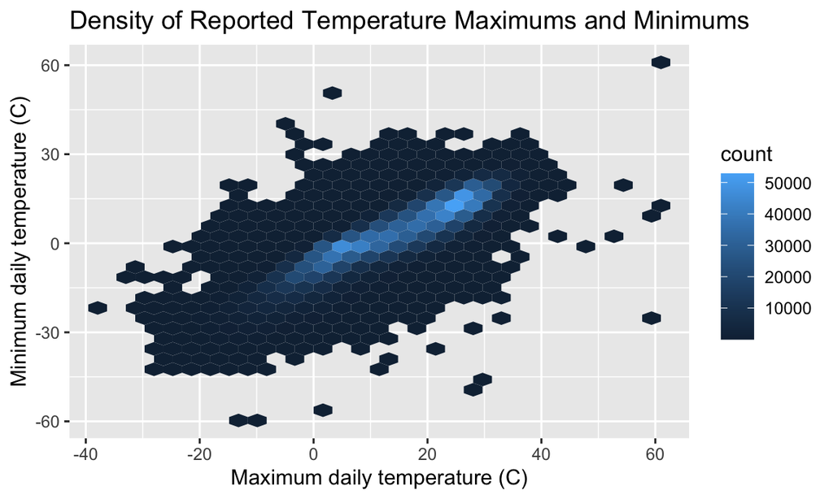

```r
hex = ggplot(ny_noaa, aes(x = tmax, y = tmin)) +
  geom_hex() +
  labs(
    title = "Density of Reported Temperature Maximums and Minimums",
    x = "Maximum daily temperature (C)",
    y = "Minimum daily temperature (C)")
hex
```

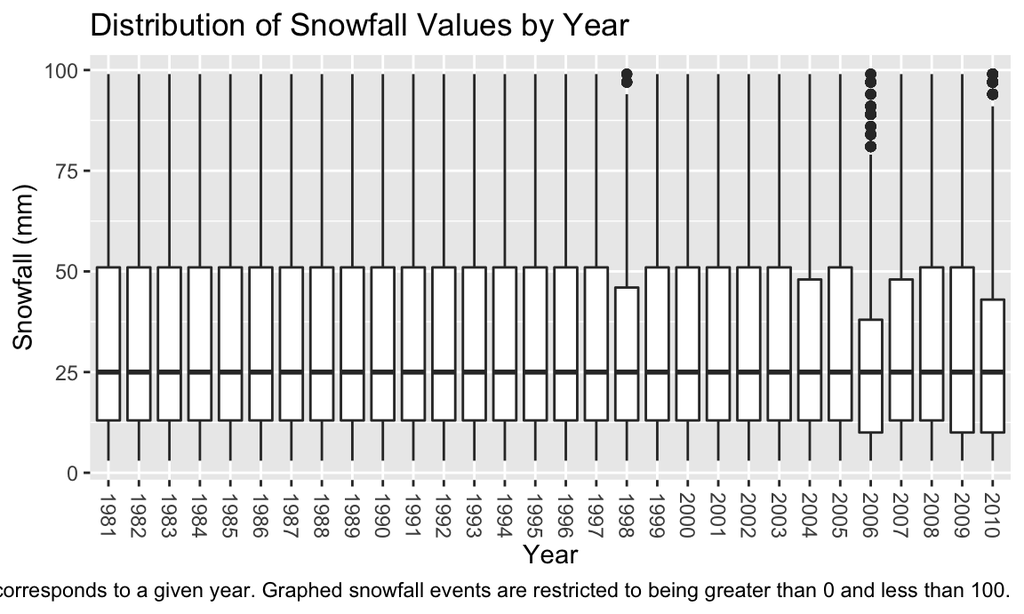

```r
snowfall_plot <- ny_noaa %>%
  filter((snow > 0) & (snow < 100)) %>%
  ggplot(aes(x = as.character(year), y = (snow))) +
  geom_boxplot() +
  labs(
    title = "Distribution of Snowfall Values by Year ",
    x = "Year",
    y = "Snowfall (mm)",
    caption = "This graph shows the distribution of snowfall values by year, where each box plot corresponds to a given year. Graphed snowfall events are restricted to being greater than 0 and less than 100.") +
  theme(axis.text.x = element_text(angle = 270, vjust = 0.5, hjust = 1))
snowfall_plot
```

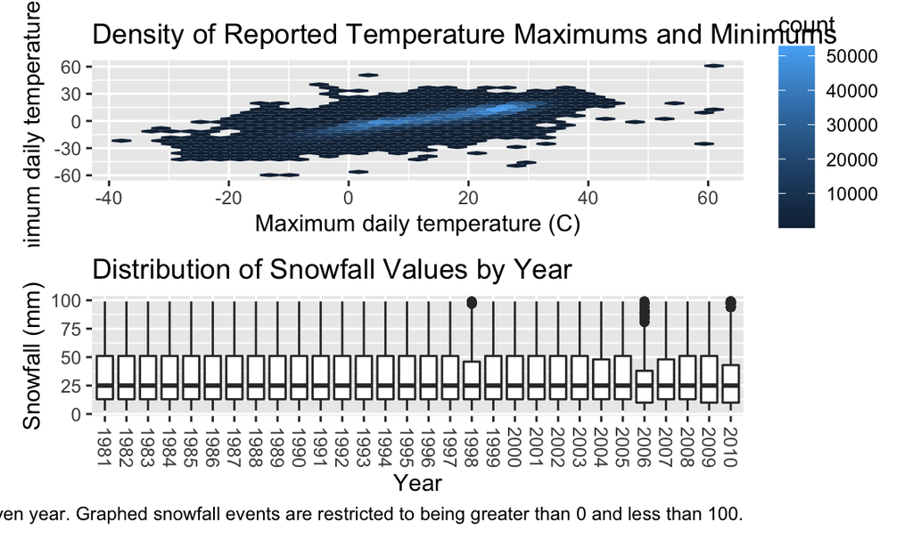

```r
##Change to mm for better looking graph

library(patchwork)
hex / snowfall_plot
```